# Project 2: Collegiate CSV file

For analysis, we are using a database of US college financial aid information made available through the US Department of Education College Affordability and Transparency Center. We hope to visualize some trends present in current college financial aid distributions throughout the nation. “Null” data points represent statstics that were unreported by their respective universities.

### Reproducing Our Work:

1. Create a GitHub repository for the project.
2. Create the folders for your project.
3. Find a csv file for statistical comparisons. Our CSV file was obtained by selecting the appropriate options from the website: http://collegecost.ed.gov/catc/Default.aspx
4. Clean up variable names using “college data wranging.r” file and use output to create SQL table in SQL Developer.
5. Import CSV into SQL Developer
6. Build an html file to document these steps.

Before generating plots, we run the ‘require.r’ file to make sure the necessary packages are in place.

```r
source("../require.R")
```

[output not shown]

### Summary and Subset:

```r
source("../01 Data/summary.R", echo = TRUE)
```

```
##
## > df <- data.frame(fromJSON(getURL(URLencode("129.152.144.84:5001/rest/native/?query=\"select * from COLLEGESTATS where tuitionfees1314 is not null\"" .... [TRUNCATED]
##
## > head(df, 10)
##                                        NAME          PUBLICPRIVATE
## 1  Rocky Mountain College of Art and Design     Private for-profit
## 2          Colorado State University-Pueblo                 Public
## 3         Western State Colorado University                 Public
## 4   Yeshiva Toras Chaim Talmudical Seminary Private not-for-profit
## 5                   Albertus Magnus College Private not-for-profit
## 6                  University of Bridgeport Private not-for-profit
## 7      Central Connecticut State University                 Public
## 8                       Connecticut College Private not-for-profit
## 9                 University of Connecticut                 Public
## 10     Eastern Connecticut State University                 Public
```

[output cut: 162 more lines]

### Plot #1:

```
##
## > df <- data.frame(fromJSON(getURL(URLencode("129.152.144.84:5001/rest/native/?query=\"select * from COLLEGESTATS where tuitionfees1314 is not null\"" .... [TRUNCATED]
##
## > head(df)
##                                       NAME          PUBLICPRIVATE
## 1 Rocky Mountain College of Art and Design     Private for-profit
## 2         Colorado State University-Pueblo                 Public
## 3        Western State Colorado University                 Public
## 4  Yeshiva Toras Chaim Talmudical Seminary Private not-for-profit
## 5                  Albertus Magnus College Private not-for-profit
## 6                 University of Bridgeport Private not-for-profit
##   GRADUATIONRATE TUITIONFEES1314 ENROLLMENTTOTAL STUDENTFACULTYRATIO
## 1             49           22470             775                   7
## 2             33            7327            7089                  15
## 3             42            7343            2404                  16
```

[output cut: 56 more lines]

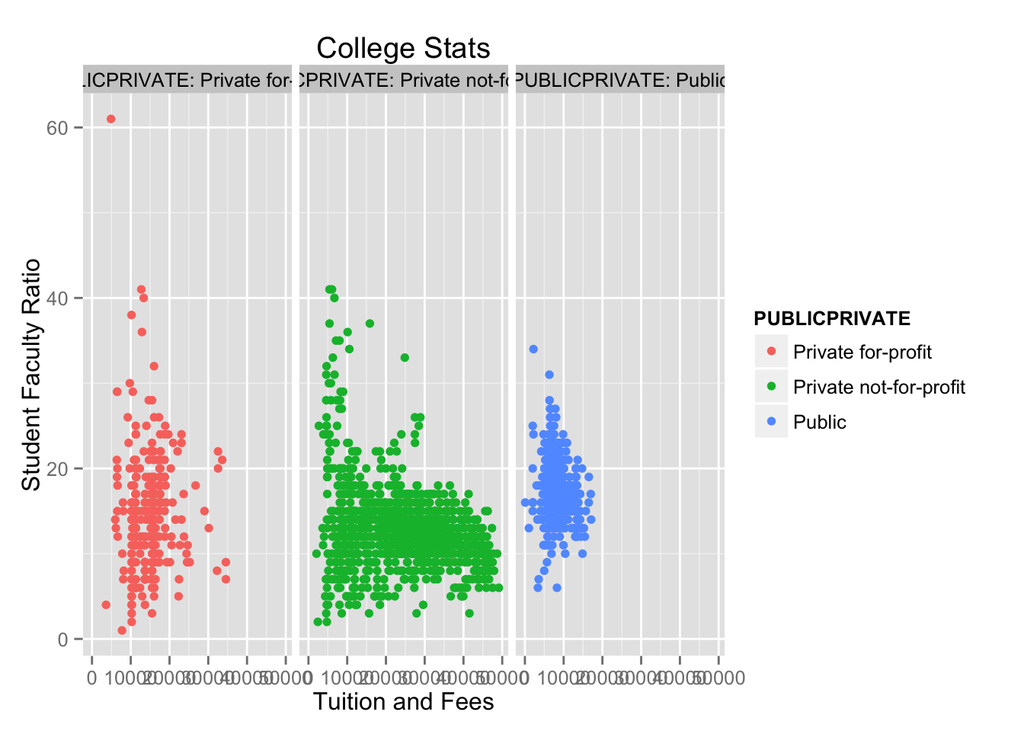

```r
source("../02 Data Wrangling/plot1.R", echo = TRUE)
```